# Flow

Dev diary of the package for computing contextual Mann-Kendall test.

We have three four stacks: noise; cell-wise AR(1)-noise; noise with trend; AR(1) noise with trend. See examples below. Most notably the trend is only present in the middle section of the region.

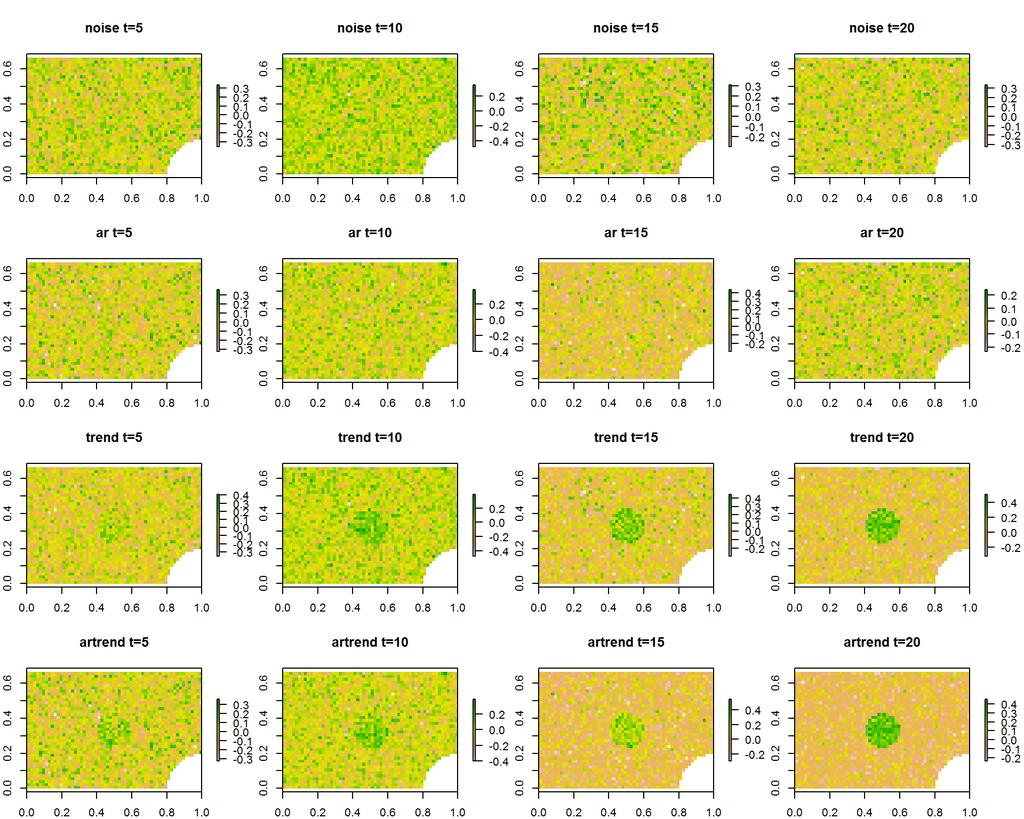

The idea of the contextual MK is that if a trend is present somewhere it should be present also nearby. This amounts to spatial-smoothing at some stage of the testing. Here is the significant cells without and with temporal correlation present:

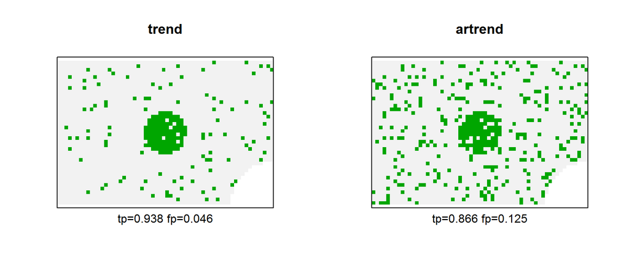

```r
fun <- function(v, ...) {
  if(sum(is.na(v))>1) return(NA)
  mann_kendall(v, est_beta = FALSE)$p
}
mk <- stackApply(stacks$trend, 1, fun)
mka <- stackApply(stacks$artrend, 1, fun)
par(mfrow=c(1,2))
plot_isit(  mk < 0.05, legend=F, main = "trend")
plot_isit(  mka< 0.05, legend=F, main = "artrend")
```

We see that we get some false positives and false negatives. The AR-errors increase clearly the false-positive rates.

The idea would be to smoothen at some point of the analysis so that only the ones at the middle are positive.

First step is to get rid of the AR-noise by “whitening” it (Wang & Swail 2001).

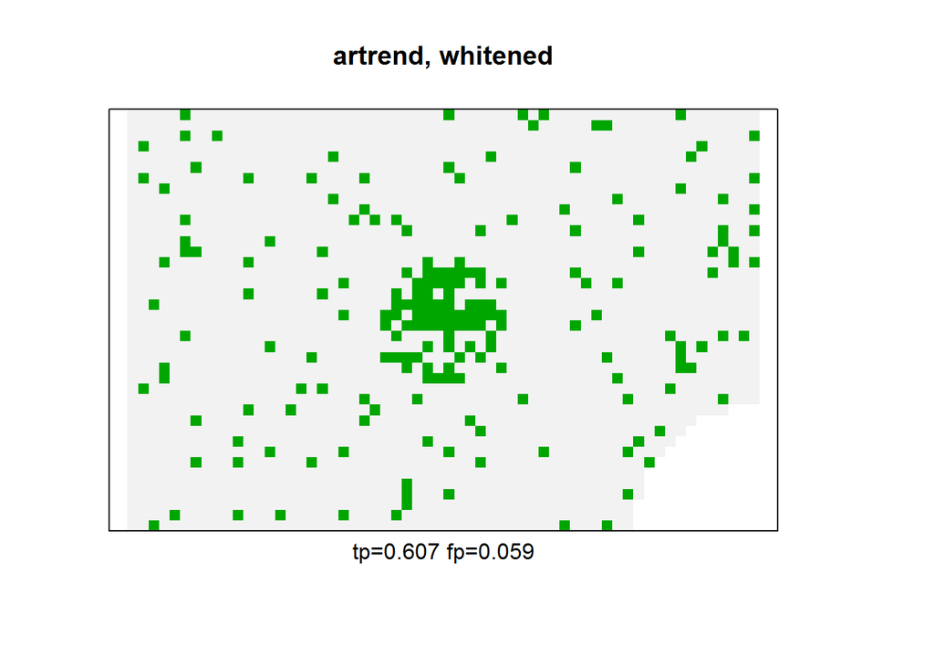

```r
sw <- wang_swail_prewhiten_stack(stacks$artrend, useC=TRUE)
stacks$artrend_w <- stack(sw[[-1]]) # drop the first NA layer lost due to whitening
mkaw <- stackApply(stacks$artrend_w, 1, fun)
plot_isit(mkaw < 0.05, legend=F, main ="artrend, whitened")
```

We can see that the FP rate of the non-AR error data and the whitened is around the requested 5%, but the AR inflates that rate. The whitening seems to work, but note how much worse the true positive rate is.

NOTE this is only one realisation, should average over more realisations.

## Smoothing

We follow the paper by Neeti&Eastman and do a “contextual MK”. First, the test statistic values are filtered with a constant weight queen-filter. And then, since the variance is changed, the new variance (per cell again, pointwise tests still) is estimated using standard variance-covariance formula.

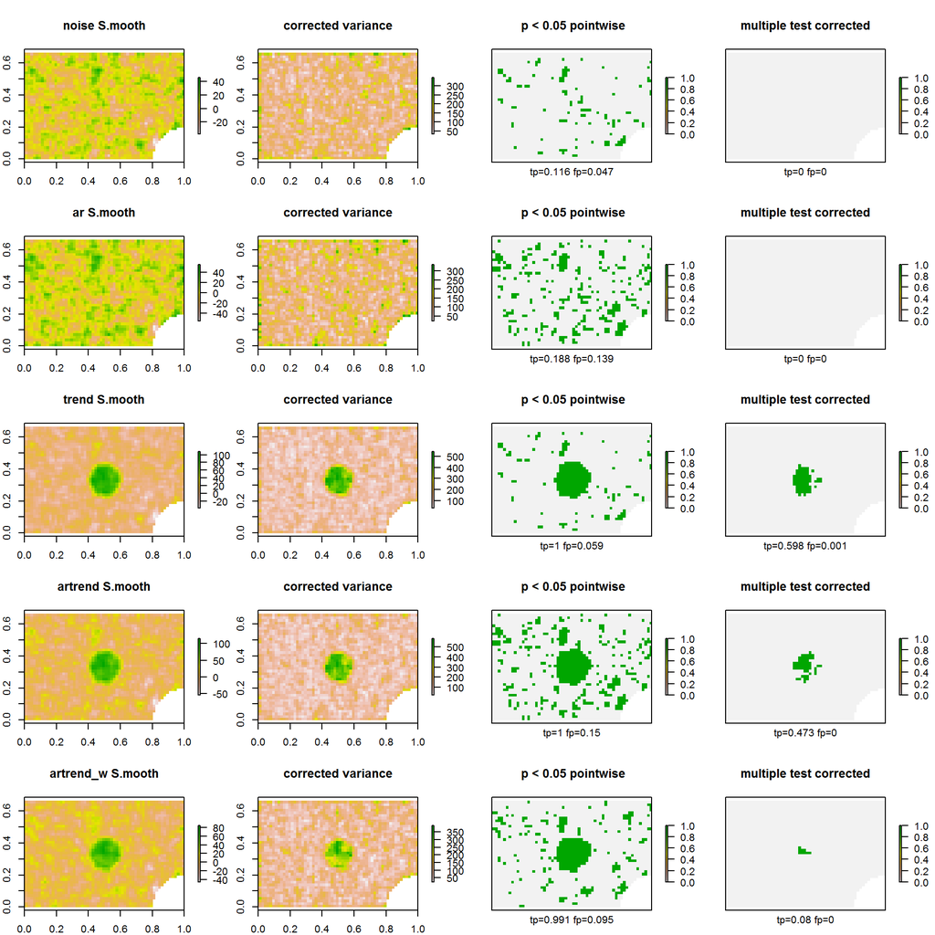

```r
cmk <- mclapply(stacks[1:5], contextual_mann_kendall)
par(mfrow=c(5,4), mar = c(2,2,4,4))

for(n in names(cmk)){
  w <- cmk[[n]]
  plot(w$Sm, main = paste0(n, " S.mooth"))
  plot(w$s2, main = "corrected variance")
  plot_isit(w$p < 0.05, main = " p < 0.05 pointwise")
  plot_isit(p = w$p, main ="multiple test corrected")
}
```

(Correction: Holm-Bonferroni)